# Lab 01

This is the first “lab” for the semester. I have included several empty code chunks and text prompts that start with “**Answer:**”. You should fill in solutions to these (code in the first case and a short answer in the second). These are not handed in or graded and solutions will be posted for next class. I suggest generally working as a group with a single shared screen, but you might want to also duplicate the code in your own machine.

## California House Prices

In this lab you will apply the methods shown in the notes to a data set of housing prices from California. Our variable of interest is the median house sale price in each census tract.

```r
set.seed(1)

ca <- read_csv(file.path("data", "ca_house_price.csv")) %>%
  mutate(train_id = if_else(runif(n()) < 0.6, "train", "valid"))
ca
```

```
## # A tibble: 5,984 x 29
##    median_house_va… population latitude longitude total_units vacant_units
##               <dbl>      <dbl>    <dbl>     <dbl>       <dbl>        <dbl>
##  1             910.       1974     37.8     -122.         929           37
##  2             749.       4865     37.8     -122.        2655          134
##  3             774.       3703     37.8     -122.        1911           68
##  4             481.       1571     37.8     -122.         781           65
##  5             439.       2302     37.8     -122.        1202           80
##  6             370.       5678     37.8     -122.        2665          500
##  7             467.       4156     37.8     -122.        2182          148
##  8             591.       2416     37.8     -122.        1372           33
##  9             352.       3528     37.8     -122.        1908          227
## 10             323.       4314     37.8     -122.        1870          432
## # … with 5,974 more rows, and 23 more variables: median_rooms <dbl>,
## #   mean_household_size_owners <dbl>, mean_household_size_renters <dbl>,
## #   built_2005_or_later <dbl>, built_2000_to_2004 <dbl>, built_1990s <dbl>,
## #   built_1980s <dbl>, built_1970s <dbl>, built_1960s <dbl>, built_1950s <dbl>,
## #   built_1940s <dbl>, built_1939_or_earlier <dbl>, bedrooms_0 <dbl>,
## #   bedrooms_1 <dbl>, bedrooms_2 <dbl>, bedrooms_3 <dbl>, bedrooms_4 <dbl>,
## #   bedrooms_5_or_more <dbl>, owners <dbl>, renters <dbl>,
## #   median_household_income <dbl>, mean_household_income <dbl>, train_id <chr>
```

There are several numeric variables that you can use to predict the output, all of which should be reasonably self-explanatory.

### Exploring the Data

To start, draw a histogram with 15 bins showing the distribution of the median house value variable:

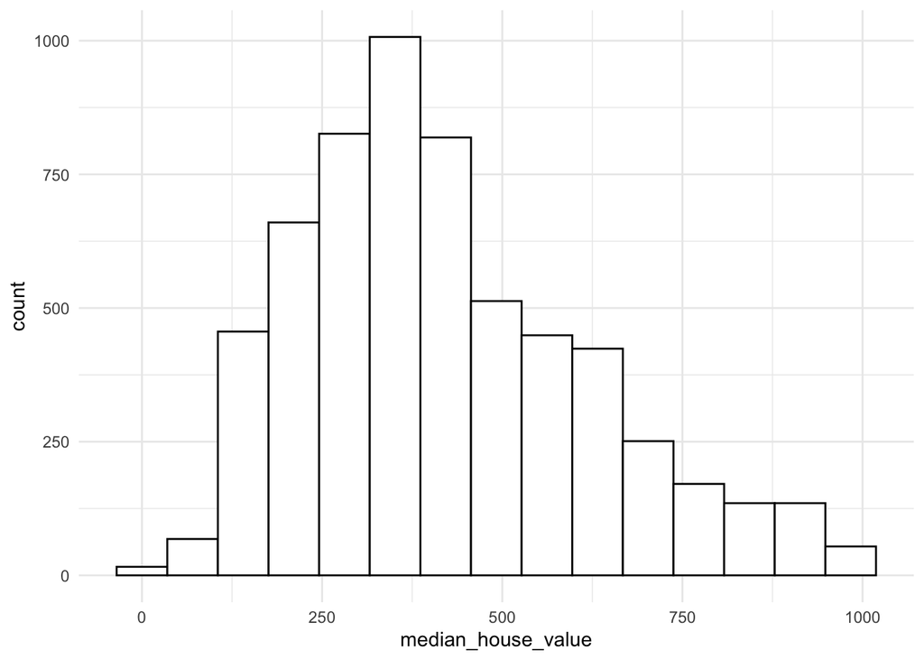

```r
ca %>%
  ggplot(aes(median_house_value)) +
    geom_histogram(bins = 15, color = "black", fill = "white")
```

What are the most typical values of the variable (they are given in thousands of dollars)? **Answer**: There are many values around $300k dollars, with a long tail ranging from near $0 to just under $1.

Now, draw a scatter plot showing the relationship between the median household income and the median house value.

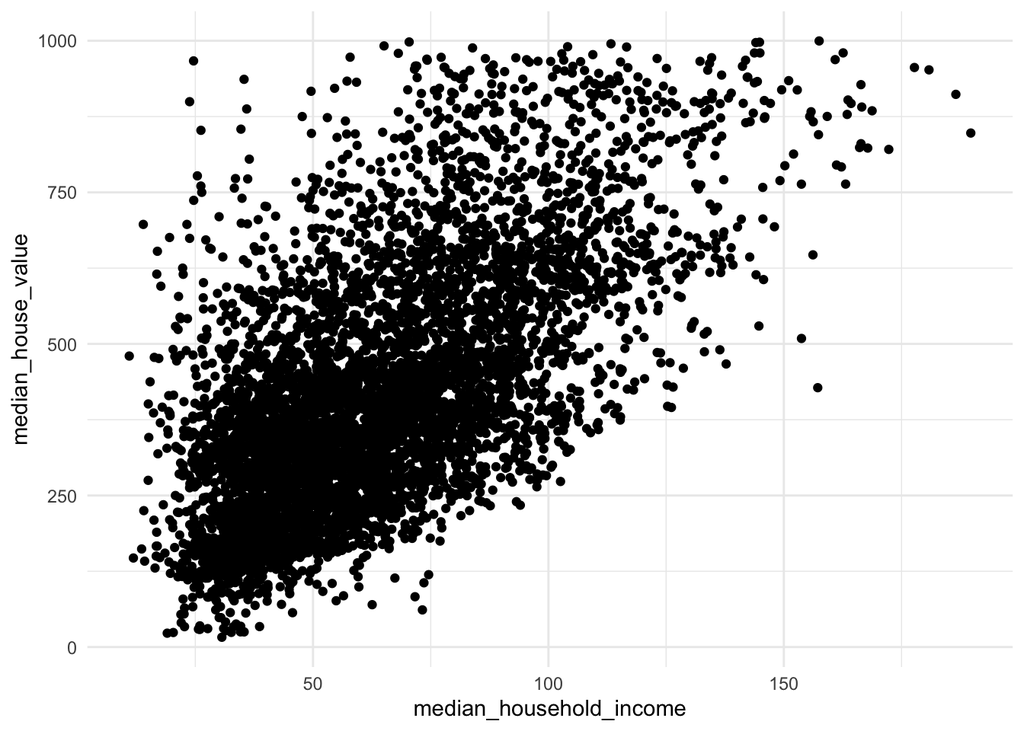

```r
ca %>%
  ggplot(aes(median_household_income, median_house_value)) +
    geom_point()
```

How would you describe this relationship? Is it surprising or as you would expect? **Answer**: In general, areas with a higher median income have more expensive houses, but the relationship has a lot of noise.

Now show the relationship between the mean household income and the median house value.

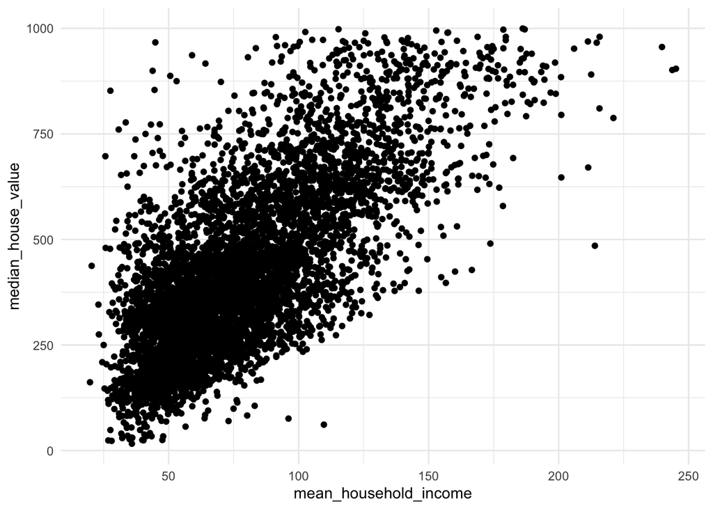

```r
ca %>%
  ggplot(aes(mean_household_income, median_house_value)) +
    geom_point()
```

How does this compare to the previous plot? **Answer**: The relationship is very similiar, and hard to differentiate just by a quick glance.

And now, show the relationship between the mean household income and the median household income. Add a line with a slope of 1 with the following layer: `geom_abline(slope = 1, color = "orange")`.

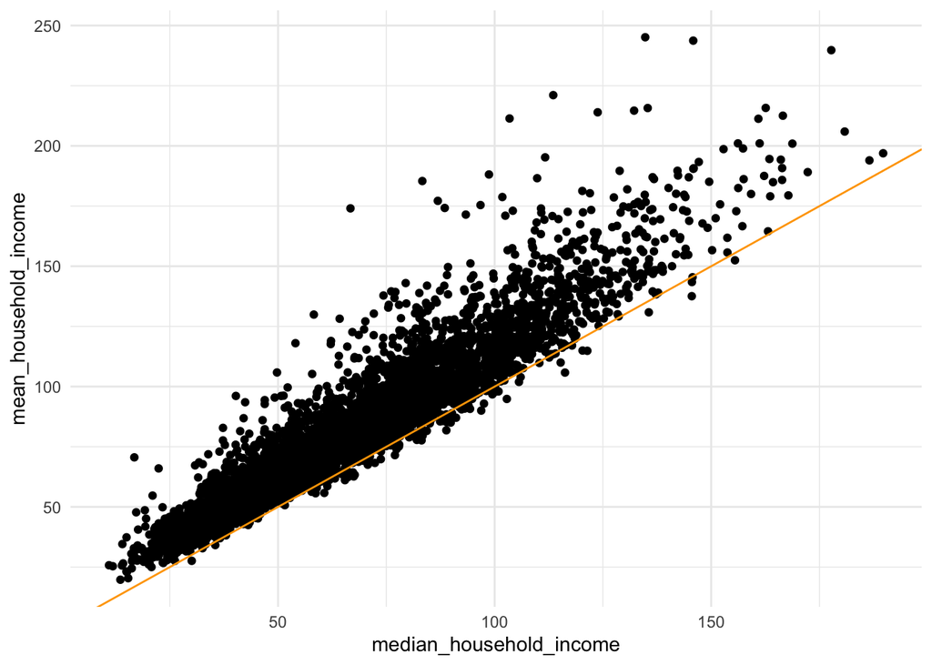

```r
ca %>%
  ggplot(aes(median_household_income, mean_household_income)) +
    geom_point() +
    geom_abline(slope = 1, color = "orange")
```

Finally, draw a scatter plot with longitude and latitude on the x- and y-axes. Color the points according to the median house value and include the scale `scale_color_viridis_c()`. You might also decrease the size to make the plot easier to read.

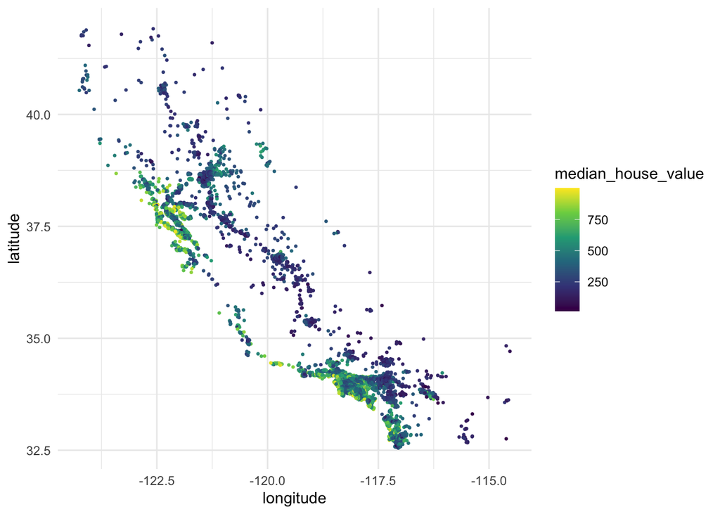

```r
ca %>%
  ggplot(aes(longitude, latitude)) +
    geom_point(aes(color = median_house_value), size = 0.5) +
    scale_color_viridis_c()
```

See if you can identify the San Francisco, Los Angeles, and San Diego metro regions. Where do you see the highest house values? How about the lowest house values? **Answer**: The highest house values are in the three large metro areas, particularly San Francisco. Lowest prices are inland.

### Simple Linear Models

Now, produce a linear model that predicts the median house value as a function of the median household income. Make sure to use only the training data. Print out a summary of the model.

```r
model <- ca %>%
  filter(train_id == "train") %>%
  lm(median_house_value ~ median_household_income, data = .)

summary(model)
```

```
##
## Call:
## lm(formula = median_house_value ~ median_household_income, data = .)
##
## Residuals:
##     Min      1Q  Median      3Q     Max
## -435.70 -109.56  -20.98   85.82  670.36
##
## Coefficients:
##                          Estimate Std. Error t value Pr(>|t|)
## (Intercept)             116.02927    6.54264   17.73   <2e-16 ***
## median_household_income   4.75483    0.09529   49.90   <2e-16 ***
## ---
## Signif. codes:  0 '***' 0.001 '**' 0.01 '*' 0.05 '.' 0.1 ' ' 1
##
## Residual standard error: 153.5 on 3618 degrees of freedom
## Multiple R-squared:  0.4076, Adjusted R-squared:  0.4075
## F-statistic:  2490 on 1 and 3618 DF,  p-value: < 2.2e-16
```

Describe in words what the model thinks is the relationship between the median household income and the median house value. **Answer**: The model thinks that each extra dollar of median household income increases the typically value of the house value by $4.75.

Using the model you just created, compute the RMSE for the training and validation sets.

```r
ca %>%
  mutate(value_pred_lm = predict(model, newdata = .)) %>%
  group_by(train_id) %>%
  summarize(rmse = sqrt(mean((median_house_value - value_pred_lm)^2)))
```

```
## # A tibble: 2 x 2
##   train_id  rmse
##   <chr>    <dbl>
## 1 train     153.
## 2 valid     153.
```

It’s hard to see how good this prediction is without a reference point. Compute the RMSE that comes from using the mean of the median house value as a predictor.

```r
ca %>%
  mutate(value_pred_const = mean(median_house_value)) %>%
  group_by(train_id) %>%
  summarize(rmse = sqrt(mean((median_house_value - value_pred_const)^2)))
```

```
## # A tibble: 2 x 2
##   train_id  rmse
##   <chr>    <dbl>
## 1 train     199.
## 2 valid     200.
```

How does the RMSE of the linear model compare to the constant model? Does the linear model seem to perform significantly better? **Answer**: Yes! The simple model has an RMSE just under 200 whereas the linear regression is around 154.

To illustrate the linear model, draw a scatter plot with median household income on the x-axis, median house value on the y-axis, and a line showing the predicted linear model.

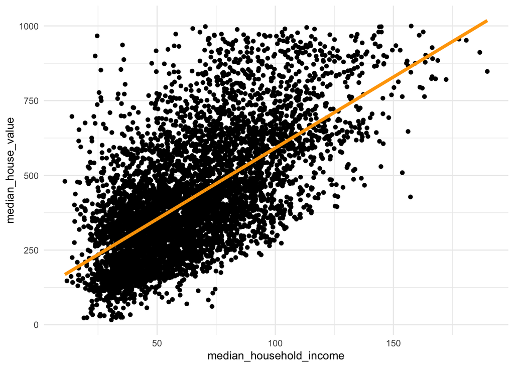

```r
ca %>%
  mutate(value_pred_lm = predict(model, newdata = .)) %>%
  ggplot(aes(median_household_income, median_house_value)) +
    geom_point() +
    geom_line(aes(y = value_pred_lm), color = "orange", size = 1.5)
```

Confirm that the linear seems to pass through the cloud of data in a reasonable way.

Now, produce a linear regression model that uses the mean household income to predict the median house value. Print out a summary of the model.

```r
model <- ca %>%
  filter(train_id == "train") %>%
  lm(median_house_value ~ mean_household_income, data = .)

summary(model)
```

```
##
## Call:
## lm(formula = median_house_value ~ mean_household_income, data = .)
##
## Residuals:
##     Min      1Q  Median      3Q     Max
## -553.38  -98.31  -14.07   78.33  636.67
##
## Coefficients:
##                       Estimate Std. Error t value Pr(>|t|)
## (Intercept)           62.91461    6.17077   10.20   <2e-16 ***
## mean_household_income  4.55971    0.07375   61.83   <2e-16 ***
## ---
## Signif. codes:  0 '***' 0.001 '**' 0.01 '*' 0.05 '.' 0.1 ' ' 1
##
## Residual standard error: 139.1 on 3618 degrees of freedom
## Multiple R-squared:  0.5137, Adjusted R-squared:  0.5136
## F-statistic:  3822 on 1 and 3618 DF,  p-value: < 2.2e-16
```

How do the slope and intercept compare to the previous model? **Answer**: The slope is actually quite close (4.5 instead of 4.75). The intercept is lower though, likely to account for the fact that the mean household income often being larger than the median household income.

Now, compute the RMSE of this model.

```r
ca %>%
  mutate(value_pred_lm = predict(model, newdata = .)) %>%
  group_by(train_id) %>%
  summarize(rmse = sqrt(mean((median_house_value - value_pred_lm)^2)))
```

```
## # A tibble: 2 x 2
##   train_id  rmse
##   <chr>    <dbl>
## 1 train     139.
## 2 valid     139.
```

Which seems to be a more powerful estimator, the mean income or the median income of each region? **Answer**: The mean income has an RMSE around 138, less than the previous model. It seems that mean income is a better predictor than median income.

### Multivariate Linear Models

We will finish by producing multivariate linear regression models using more than one predictor variable. Fit a regression model that uses both the mean household income and the median household income to predict the house value. Print out a summary of the model.

```r
model <- ca %>%
  filter(train_id == "train") %>%
  lm(median_house_value ~ mean_household_income + median_household_income, data = .)

summary(model)
```

```
##
## Call:
## lm(formula = median_house_value ~ mean_household_income + median_household_income,
##     data = .)
##
## Residuals:
##     Min      1Q  Median      3Q     Max
## -692.74  -98.97   -9.29   78.85  602.49
##
## Coefficients:
##                         Estimate Std. Error t value Pr(>|t|)
## (Intercept)              64.4074     6.0777   10.60   <2e-16 ***
## mean_household_income     6.8288     0.2241   30.48   <2e-16 ***
## median_household_income  -2.8079     0.2623  -10.70   <2e-16 ***
## ---
## Signif. codes:  0 '***' 0.001 '**' 0.01 '*' 0.05 '.' 0.1 ' ' 1
##
## Residual standard error: 137 on 3617 degrees of freedom
## Multiple R-squared:  0.5287, Adjusted R-squared:  0.5284
## F-statistic:  2028 on 2 and 3617 DF,  p-value: < 2.2e-16
```

What are the signs of the slope parameters? Do these surprise you? **Answer**: The mean household income has a positive sign, but the median household income has a negative sign. The phenomenon of a parameter switching sign in a multivariate model is common when we have two highly-correlated variables.

Compute the RMSE of this new model on the training and validation sets.

```r
ca %>%
  mutate(value_pred_lm = predict(model, newdata = .)) %>%
  group_by(train_id) %>%
  summarize(rmse = sqrt(mean((median_house_value - value_pred_lm)^2)))
```

```
## # A tibble: 2 x 2
##   train_id  rmse
##   <chr>    <dbl>
## 1 train     137.
## 2 valid     136.
```

How does this compare to the RMSE of the previous models? **Answer**: The RMSE decreases very slightly compared to the previous model, from 138.5 down to 136.5.

Produce a scatter plot with median household income on the x-axis, mean household income on the y-axis, and the points colored according the predicted value from the linear model. Use the viridis color scale mentioned in the previous question.

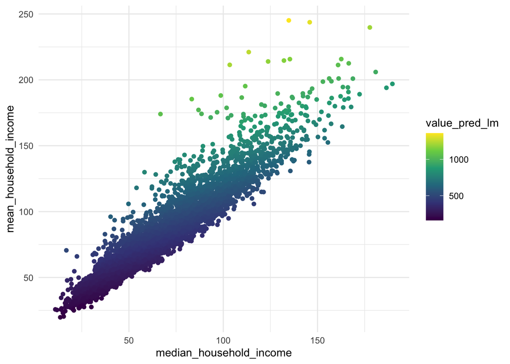

```r
ca %>%
  mutate(value_pred_lm = predict(model, newdata = .)) %>%
  ggplot(aes(median_household_income, mean_household_income)) +
    geom_point(aes(color = value_pred_lm)) +
    scale_color_viridis_c()
```

Can you see the effect of the two different coefficients that were found in the linear regression model?

### Build Your Own

Before finishing, try to build a more predictive model using any other variables that you think might be useful. Compute the RMSE of the training and validation set and feel free to iterate a few times to get the best fit.

```r
model <- ca %>%
  filter(train_id == "train") %>%
  lm(median_house_value ~ mean_household_income +
                          median_household_income +
                          latitude +
                          longitude +
                          mean_household_size_renters +
                          built_1939_or_earlier +
                          bedrooms_1 +
                          bedrooms_2, data = .)

ca %>%
  mutate(value_pred_lm = predict(model, newdata = .)) %>%
  group_by(train_id) %>%
  summarize(rmse = sqrt(mean((median_house_value - value_pred_lm)^2)))
```

```
## # A tibble: 2 x 2
##   train_id  rmse
##   <chr>    <dbl>
## 1 train     103.
## 2 valid     104.
```

I was able to get a model with an RMSE just slightly above 100.